# Anàlisi dels acudits de Jaimito: scraping

Àngel Rosado i Mónica Salgado

20/5/2017

Els acudits de Jaimito són coneguts per tothom, i tothom sap que no són gaire bons. A aquest treball ens proposem fer scraping d’una web d’acudits i veure de manera gráfica quines són les paraules més comuns a aquest tipus d’acudits.

```r
library(rvest)
library(stringr)
library(tm)
library(wordcloud)
library(RColorBrewer)
```

Ara, farem l’scraping dels acudits de la pàgina “http://www.chistescortosbuenos.com/chistes-de-jaimito-11” i agarem els acudits de la pàgina 1, 2 i 3 (en total 45 acudits). Per trobar l’etiqueta per saber que havíem de descarregar, hem emprat l’extensió del navegador “Selector gadget” que ens ha dit que haviem de descarregar els elements etiquetats amb ‘.chiste’.

```r
url <- c('http://www.chistescortosbuenos.com/chistes-de-jaimito-11',
        'http://www.chistescortosbuenos.com/chistes-de.php?cat=11&page=2',
        'http://www.chistescortosbuenos.com/chistes-de.php?cat=11&page=3')
chistes <- c()
for(i in 1:3){
  chistes5 <- read_html(url[i]) %>%
    html_nodes('.chiste') %>%
    html_text()
  chistes <- c(chistes,chistes5[2:16])
}
```

## Selecció de l’acudit

A aquesta secció eliminarem dels acudits baixats els elements que no ens interesen - El principi, on possa el dia i hora en què es va pujar al web. - El final on hi possa la paraula “Compartir”. Per fer-ho emprarem expressions regulars i cercarem un any (201X) en el primer cas i la paraula “Compartir” en el segon.

```r
chistes2 <- c()

for(i in 1:length(chistes)){
  text1 <- chistes[i]
  my_pattern <- "201*[0-9]"
  string_pos1 <- str_locate(text1, my_pattern)
  my_pattern2 <- "Compartir"
  string_pos2 <- str_locate(text1, my_pattern2)
  chistes2[i] <- substr(text1,start = string_pos1+4,string_pos2-1)
}
chistes2
```

```
##  [1] "\nJaimito protesta por deberes\nJaimito protesta: -¡Uf, qué rollo, me apetece ver la tele pero tengo una montaña de deberes pendientes, vaya aburrimiento! Su madre le responde: -Vamos, Jaimito, que yo sepa, aún no se ha muerto nadie por hacer los deberes. Y Jaimito le replica: -Sí claro, pe…
##  [2] "\nJaimito y el loro que no está\nSu madre le dice a Jaimito: -El loro no está en la jaula, ¿qué ha pasado? Y Jaimito responde: -No lo sé, mamá, pero hace cinco minutos me ha parecido que el gato estaba hablando. "
##  [3] "\nJaimito conjugando verbos\nLa profesora le dice a Jaimito: -Jaimito, conjuga el verbo caminar: -Yo camino, tú caminas, él camina... -¡Más de prisa! -Nosotros corremos, vosotros corréis, ellos corren...  "
##  [4] "\nLos buzos nunca se tiran para adelante\nAdivina por qué los buzos nunca se tiran de cabeza hacia delante. Porque si se tiraran hacia delante se darían con la nariz en el suelo "
##  [5] "\nPepito y el cero\nEl profesor repartiendo las notas: -Luisito un diez, Pedrito un ocho, Juanito un seis, Pepito un cero. -Oiga profesor, ¿y por qué a mi un cero? -Porque has copiado el examen de Pedrito. -¿Y usted cómo lo sabe? Porque las cuatro primeras preguntas eran iguales, y en la úl…
##  [6] "\nLa maestra que se enfada con Jaimito por la adivinanza\nFin de año. La maestra realiza diferentes juegos con los niños en la escuela. También se encuentra Jaimito, con una mano en el bolsillo y preguntando: -Maestra, ¿qué tengo en la mano? Tiene cuatro centímetros y una cabeza roja... La …
##  [7] "\nJaimito enamorado de Rosita\nJaimito, de siete años, está enamorado de Rosita, la niña de sus vecinos. Un día dice a su padre que quiere casarse. -¿Y cómo te las apañarás para ganar dinero? -Bueno, cuento con tu asignación semanal, y Rosita tiene casi diez euros en su hucha. -No está mal …
##  [8] "\nJaimito y su pelea en la escuela\nLa madre se queja de que Jaimito viene hecho polvo de la escuela: -¿Por qué vienes así? -Es que un niño me ha pegado. -Voy a ir ahora mismo a quejarme al director. ¿Tú podrás reconocer a ese chico? -¡Claro que sí mamá! ¡Tengo un pedazo de su oreja en el b…
##  [9] "\nLas iglesias y los botiquines\n¿En qué se parece un botiquín a una iglesia? -En que en los dos hay curas "
## [10] "\nPara verse todavía con pelo.\n-Se me cae el pelo, ¿cómo haré para verme todavía con el que me queda? -Retrátate rápido, antes de que se te caiga del todo. "
## [11] "\nSobre cómo hacer que un andaluz trabaje\n-¿Sabes cuál es la mejor manera de lograr que un andaluz haga algo? -Decirle que, tal vez, sea demasiado viejo para hacerlo. "
## [12] "\nLos azucarillos de Jaimito\nJaimito en un bar preguntándole al camarero: -¿me puede traer otro azucarillo? -El camarero, un poco irritado, le dice: -¡Es el décimo azucarillo que te traigo¡ -¿Y que culpa tengo yo si todos se deshacen?"
## [13] "\nLa novia que tenía kilos de más\nEra tan gorda, que su novio le decía: Adoro cada área de tu cuerpo "
## [14] "\nEl maquillaje de la tia de Jaimito\nJaimito le dice a su tia: -¡Muy maquillada estás! ¿Para qué te pintas tanto? -Hay Jaimito, es para estar más guapa... -Ah... ¿Y cuanto tarda en hacer efecto? "
## [15] "\nJaimito en el dentista y los 5 dientes\nJaimito con la madre en el dentista, le dice el doctor: -Tienes la dentadura fatal, así que tendré que quitarte 5 dientes y una muela! -¡Mamá, mamá! ¡Mira lo que dice el dentista! -Doctor! ¿Eso es normal? ¿Le va a doler? -Pues es normal, y en cuanto…
```

[output cut: 30 more lines]

## Un poc de text mining

Ara, introduïm cadascun dels acudits en un objecte “VCorpus”.

```r
chistes.corpus <- Corpus(VectorSource(chistes2))
```

A continuació eliminam els espais en blanc dels acudits ja que no ens donaran informació que sigui relevant. També canviam les lletres majúscules per minúscules i eliminam els signes de puntuació.

```r
#Eliminam els espais blancs
chistes.corpus <- tm_map(chistes.corpus, stripWhitespace)

#Canviam les lletres majúscules per minúscules.
chistes.corpus <- tm_map(chistes.corpus, content_transformer(tolower))

#Eliminam bots de linia entre altres coses.
codigos <- "\u0080|\u0085|\u0093|\u0094|\u0096|\u0096|\u0097"
chistes.corpus<- tm_map(chistes.corpus, content_transformer(gsub),
                   pattern = codigos, replacement = "")

#Eliminam els signes de puntuació.
replacePunctuation <- content_transformer(function(x)
  {return (gsub("[[:punct:]]"," ", x))})
chistes.corpus <- tm_map(chistes.corpus, replacePunctuation )
```

També eliminam les paraules buides de contingut o que venen per defecte al paquet de R en castellà i a les que afegirem les paraules ‘pues’, ‘dice’, ‘cómo’, ‘tan’, ‘mientras’ “niño”, “niña”, “niños” i “niñas” que hem notat que no hi sortien a les de R i que tampoc aporten res. Per acabar el tractament previ dels acudits eliminarem els accents que hi apareixen, així evitarem problemes futurs de que una mateixa paraula escrita dues vegades, a una li hagin possat accent i a altre no.

```r
excluidas <- c(stopwords("spanish"), "pues", "dice", "cómo", "tan",
               "mientras", "niño", "niña", "niños", "niñas")
chistes.corpus <- tm_map(chistes.corpus, removeWords, excluidas)

accents = c("á","é","í","ó","ú")
sense_accents = c("a","e","i","o","u")
for (i in 1:5){
  chistes.corpus <- tm_map(chistes.corpus, content_transformer(gsub),
                     pattern = accents[i], replacement = sense_accents[i])
}
```

Per acabar farem un núvol de paraules amb les paraules dels acudits per tenir de manera ràpida i molt visual quines paraules apareixen més.

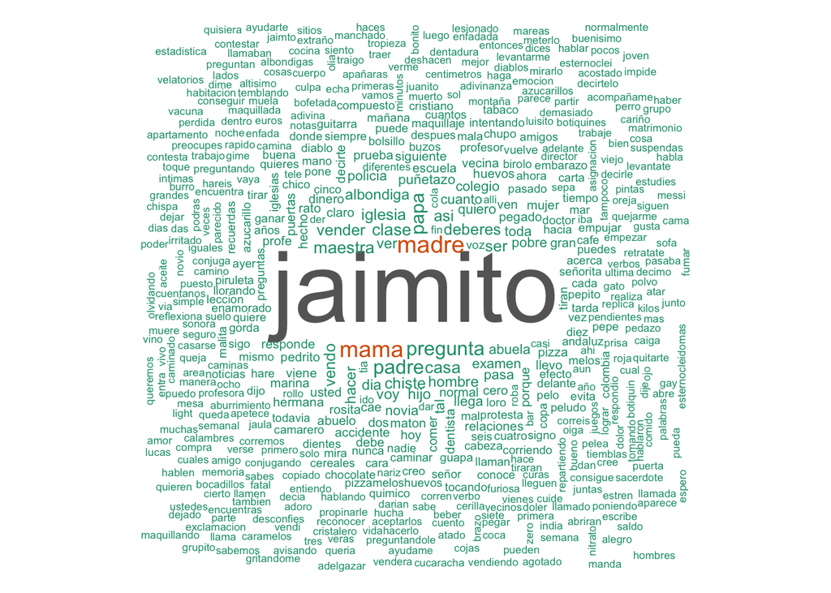

```r
#Ara feim un núvol de paraules amb les paraules que apareixen.

filtrat <- function(corpus, dict=NULL) {
  if (is.null(dict))
    TermDocumentMatrix(corpus)
  else
    TermDocumentMatrix(corpus, control = list(dictionary = dict))
}

p11 <- filtrat(chistes.corpus)
veces <- 1
mChistes1 <- as.matrix(p11)
frecuencias1 <- sort(rowSums(mChistes1), decreasing = TRUE)
pal21 <- brewer.pal(8,"Dark2")
set.seed(21746)
wordcloud(words=names(frecuencias1), freq=frecuencias1, scale = c(5, 0.5), min.freq=veces,
          random.order=F, colors=pal21)
```